# Rworkshop by Shelmith Kariuki on Tidyverse

Wilfred Mambina

2/18/2020

#loading packages

```r
library(tidyverse)
```

#load data

```r
datax<-read_csv("D:/Statistician/data_archive/Rworkshop/Wafanyikazi.csv")
```

Comment:Wafanyikazi dataset is data that consists labor force details in Kenya #Checking structure of the data

```r
str(datax)
```

```
## tibble [500 x 11] (S3: spec_tbl_df/tbl_df/tbl/data.frame)
##  $ X1            : num [1:500] 1 2 3 4 5 6 7 8 9 10 ...
##  $ Sid           : num [1:500] 10715 17041 16232 19576 13463 ...
##  $ Gender        : chr [1:500] "Male" "Male" "Male" "Female" ...
##  $ Age           : num [1:500] 31 48 35 41 43 30 45 19 44 34 ...
##  $ Department    : chr [1:500] "Finance" "Research Analyst" "Operations" "Finance" ...
##  $ Role          : chr [1:500] "Mid" "Junior" "Junior" "Senior" ...
##  $ Income        : num [1:500] 5991 3387 3170 5557 1651 ...
##  $ Marital_Status: chr [1:500] "Single" "Divorced" "Married" "Married" ...
##  $ County        : chr [1:500] "Kisumu" "Wajir" "Mombasa" "Nyeri" ...
##  $ Leave_Days    : num [1:500] 11 8 0 8 2 9 12 12 13 4 ...
##  $ Promotion     : chr [1:500] "No" "Yes" "No" "No" ...
##  - attr(*, "spec")=
##   .. cols(
##   ..   X1 = col_double(),
##   ..   Sid = col_double(),
##   ..   Gender = col_character(),
##   ..   Age = col_double(),
##   ..   Department = col_character(),
##   ..   Role = col_character(),
##   ..   Income = col_double(),
##   ..   Marital_Status = col_character(),
##   ..   County = col_character(),
##   ..   Leave_Days = col_double(),
##   ..   Promotion = col_character()
##   .. )
```

```r
head(datax)
```

```
## # A tibble: 6 x 11
##      X1   Sid Gender   Age Department Role  Income Marital_Status County
##   <dbl> <dbl> <chr>  <dbl> <chr>      <chr>  <dbl> <chr>          <chr>
## 1     1 10715 Male      31 Finance    Mid     5991 Single         Kisumu
## 2     2 17041 Male      48 Research ~ Juni~   3387 Divorced       Wajir
## 3     3 16232 Male      35 Operations Juni~   3170 Married        Momba~
## 4     4 19576 Female    41 Finance    Seni~   5557 Married        Nyeri
## 5     5 13463 Female    43 Associate  Juni~   1651 Married        Nairo~
## 6     6 19788 Female    30 Finance    Juni~   6859 Single         Taita
## # ... with 2 more variables: Leave_Days <dbl>, Promotion <chr>
```

#Checking dimension of the dataset

```r
dim(datax)
```

```
## [1] 500  11
```

Comment:The dataset has 500 observations and 11 variables #Select gender and age variables

```r
age_gender <-datax%>%
  select(Age, Gender)
head(age_gender)
```

```
## # A tibble: 6 x 2
##     Age Gender
##   <dbl> <chr>
## 1    31 Male
## 2    48 Male
## 3    35 Male
## 4    41 Female
## 5    43 Female
## 6    30 Female
```

```r
attach(datax)
```

#Dropping varibles by the use of - sign

```r
drop<-datax %>%
select(-X1)
```

Comment:We have dropped X1 variable(column) using minus(-)sign #Check variables that starts with A

```r
starts_a <-datax%>%
  select(starts_with("A"))
head(starts_a)
```

```
## # A tibble: 6 x 1
##     Age
##   <dbl>
## 1    31
## 2    48
## 3    35
## 4    41
## 5    43
## 6    30
```

Comment:In this case our variable Age starts with A #Contains letter a

```r
contains_a <- datax%>%
  select(contains("A"))
head(contains_a)
```

```
## # A tibble: 6 x 4
##     Age Department       Marital_Status Leave_Days
##   <dbl> <chr>            <chr>               <dbl>
## 1    31 Finance          Single                 11
## 2    48 Research Analyst Divorced                8
## 3    35 Operations       Married                 0
## 4    41 Finance          Married                 8
## 5    43 Associate        Married                 2
## 6    30 Finance          Single                  9
```

Comment:The four variables above contains letter a on them. #Ends with letter t

```r
ends_t <-datax %>%
  select(ends_with("t"))
head(ends_t)
```

```
## # A tibble: 6 x 1
##   Department
##   <chr>
## 1 Finance
## 2 Research Analyst
## 3 Operations
## 4 Finance
## 5 Associate
## 6 Finance
```

Comment:In our case it means that Department is the only variable that ends with letter t #Filtering Filter()help us to choose cases where the condition is True #Filtering only Female

```r
female_data <-datax%>%
  filter(Gender == "Female")
head(female_data)
```

```
## # A tibble: 6 x 11
##      X1   Sid Gender   Age Department Role  Income Marital_Status County
##   <dbl> <dbl> <chr>  <dbl> <chr>      <chr>  <dbl> <chr>          <chr>
## 1     4 19576 Female    41 Finance    Seni~   5557 Married        Nyeri
## 2     5 13463 Female    43 Associate  Juni~   1651 Married        Nairo~
## 3     6 19788 Female    30 Finance    Juni~   6859 Single         Taita
## 4    15 16384 Female    32 Operations Mid     9463 Single         Kiambu
## 5    18 10415 Female    35 Associate  Juni~   3604 Single         Embu
## 6    21 18197 Female    26 Data       Seni~   1868 Married        Laiki~
## # ... with 2 more variables: Leave_Days <dbl>, Promotion <chr>
```

#Filter Age 30 and below

```r
age_30 <-datax%>%
  filter(Age <= 30)
head(age_30)
```

```
## # A tibble: 6 x 11
##      X1   Sid Gender   Age Department Role  Income Marital_Status County
##   <dbl> <dbl> <chr>  <dbl> <chr>      <chr>  <dbl> <chr>          <chr>
## 1     6 19788 Female    30 Finance    Juni~   6859 Single         Taita
## 2     8 13847 Male      19 Research ~ Mid     5123 Divorced       Taita
## 3    11 13936 Male      21 Research ~ Seni~   7076 Divorced       Nyeri
## 4    16 12463 Male      19 Associate  Juni~   2519 Single         Embu
## 5    17 15643 Male      20 Operations Seni~   1217 Married        Taita
## 6    20 10665 Male      18 Associate  Juni~   8161 Married        Kisumu
## # ... with 2 more variables: Leave_Days <dbl>, Promotion <chr>
```

```r
female_nyeri <-datax %>%
  filter(Gender == "Female" & County == "Nyeri" &
           Age >= 26 & Income < 5000)
head(female_nyeri)
```

```
## # A tibble: 6 x 11
##      X1   Sid Gender   Age Department Role  Income Marital_Status County
##   <dbl> <dbl> <chr>  <dbl> <chr>      <chr>  <dbl> <chr>          <chr>
## 1    83 13869 Female    29 Finance    Juni~   3387 Divorced       Nyeri
## 2   163 13697 Female    34 Operations Juni~   1217 Married        Nyeri
## 3   194 10562 Female    27 Finance    Juni~   2736 Divorced       Nyeri
## 4   246 10215 Female    34 Research ~ Mid     2953 Married        Nyeri
## 5   282 12955 Female    47 Finance    Mid     4472 Single         Nyeri
## 6   299 18342 Female    42 Associate  Seni~   1000 Married        Nyeri
## # ... with 2 more variables: Leave_Days <dbl>, Promotion <chr>
```

#Filter females and exclude Juniors earning >6000

```r
females_None_Jnr <-datax %>%
  filter(Gender == "Female" & Income > 6000 & Role != "Junior")
head(females_None_Jnr)
```

```
## # A tibble: 6 x 11
##      X1   Sid Gender   Age Department Role  Income Marital_Status County
##   <dbl> <dbl> <chr>  <dbl> <chr>      <chr>  <dbl> <chr>          <chr>
## 1    15 16384 Female    32 Operations Mid     9463 Single         Kiambu
## 2    38 13683 Female    36 Operations Seni~   7076 Single         Lamu
## 3    44 15292 Female    22 Finance    Seni~   7510 Married        Momba~
## 4    49 18772 Female    34 Research ~ Seni~   7944 Married        Laiki~
## 5    64 15883 Female    18 Operations Seni~   6642 Divorced       Momba~
## 6    67 19891 Female    48 Operations Seni~   9029 Married        Nyeri
## # ... with 2 more variables: Leave_Days <dbl>, Promotion <chr>
```

#Mutate function

```r
income_datax <- datax %>%
  select(Income) %>%
  mutate(Income2 = Income * 100)
head(income_datax)
```

```
## # A tibble: 6 x 2
##   Income Income2
##    <dbl>   <dbl>
## 1   5991  599100
## 2   3387  338700
## 3   3170  317000
## 4   5557  555700
## 5   1651  165100
## 6   6859  685900
```

Comment:We have created a new variable by the name “Income2” which contains data values multiplied by 100 #creating swahili gender column

```r
Swahili <- datax %>%
  select(Gender) %>%
  mutate(jinsia =
           if_else(Gender == "Male", "Mme", "Mke"))
head(Swahili)
```

```
## # A tibble: 6 x 2
##   Gender jinsia
##   <chr>  <chr>
## 1 Male   Mme
## 2 Male   Mme
## 3 Male   Mme
## 4 Female Mke
## 5 Female Mke
## 6 Female Mke
```

Comment:We have created a new column which is a transformation of column1 in Swahili version. #If esle condition ifelse() helps us to shift from one condition to another

```r
Department_ifesle <-datax%>%
  select(Department) %>%
  mutate(Department2 =
           ifelse(
             Department == "Finance",
             'F',
             ifelse(
               Department == "Research Analyst" ,
               "R",
               ifelse(
                 Department == "Operations",
                 "O",
                 ifelse(Department == "Associate", "A", "D")
               )
             )
           ))
head(Department_ifesle)
```

```
## # A tibble: 6 x 2
##   Department       Department2
##   <chr>            <chr>
## 1 Finance          F
## 2 Research Analyst R
## 3 Operations       O
## 4 Finance          F
## 5 Associate        A
## 6 Finance          F
```

#Creating Age group

```r
Age_group <-datax %>%
  select(Age) %>%
  mutate(ageX =
           ifelse(Age < 25, "Young",
                  ifelse(Age > 25 & Age < 40, "Middle", "old")))
head(Age_group)
```

```
## # A tibble: 6 x 2
##     Age ageX
##   <dbl> <chr>
## 1    31 Middle
## 2    48 old
## 3    35 Middle
## 4    41 old
## 5    43 old
## 6    30 Middle
```

#Renaming using the rename() helps us to rename variables

```r
Age_miaka <-datax %>%
  rename(miaka = Age)
head(Age_miaka)
```

```
## # A tibble: 6 x 11
##      X1   Sid Gender miaka Department Role  Income Marital_Status County
##   <dbl> <dbl> <chr>  <dbl> <chr>      <chr>  <dbl> <chr>          <chr>
## 1     1 10715 Male      31 Finance    Mid     5991 Single         Kisumu
## 2     2 17041 Male      48 Research ~ Juni~   3387 Divorced       Wajir
## 3     3 16232 Male      35 Operations Juni~   3170 Married        Momba~
## 4     4 19576 Female    41 Finance    Seni~   5557 Married        Nyeri
## 5     5 13463 Female    43 Associate  Juni~   1651 Married        Nairo~
## 6     6 19788 Female    30 Finance    Juni~   6859 Single         Taita
## # ... with 2 more variables: Leave_Days <dbl>, Promotion <chr>
```

Comment:In our case we have renamed the variable Age to Miaka #Group_by Group_by works close with summarise they help us cluster common variable categories and get say statistical summaries of the same. #Group according to Gender and get the summary stats

```r
Groupby_Gender <- datax%>%
  group_by(Gender) %>%
  summarise(mean_age = mean(Age))
head(Groupby_Gender)
```

```
## # A tibble: 2 x 2
##   Gender mean_age
##   <chr>     <dbl>
## 1 Female     34.1
## 2 Male       33.0
```

#Group according to Department and get the summary stats

```r
Depart_group <-datax%>%
  group_by(Department) %>%
  summarise(mean_age = mean(Age))
head(Depart_group)
```

```
## # A tibble: 5 x 2
##   Department       mean_age
##   <chr>               <dbl>
## 1 Associate            34.3
## 2 Data                 33.7
## 3 Finance              32.2
## 4 Operations           33.5
## 5 Research Analyst     34.0
```

#Group according to county and get the summary stats

```r
county_group <-datax%>%
  group_by(County) %>%
  summarise(
    minimum = min(Income),
    max = max(Income),
    mean = mean(Income)
  )
head(county_group)
```

```
## # A tibble: 6 x 4
##   County    minimum   max  mean
##   <chr>       <dbl> <dbl> <dbl>
## 1 Embu         1000  9680 5119.
## 2 Kiambu       1000  9897 5454.
## 3 Kirinyaga    1000  9897 5308.
## 4 Kisumu       1000  9897 5888.
## 5 Laikipia     1434  9897 5979.
## 6 Lamu         1000  9897 5503.
```

#Data Vizualization #Grouping according to department & gender

```r
Dep_Gender_bar <-datax%>%
  group_by(Department, Gender) %>%
  summarise(count=n())
head(Dep_Gender_bar)
```

```
## # A tibble: 6 x 3
## # Groups:   Department [3]
##   Department Gender count
##   <chr>      <chr>  <int>
## 1 Associate  Female    43
## 2 Associate  Male      51
## 3 Data       Female    50
## 4 Data       Male      53
## 5 Finance    Female    49
## 6 Finance    Male      56
```

# Distribution Per Department & Gender

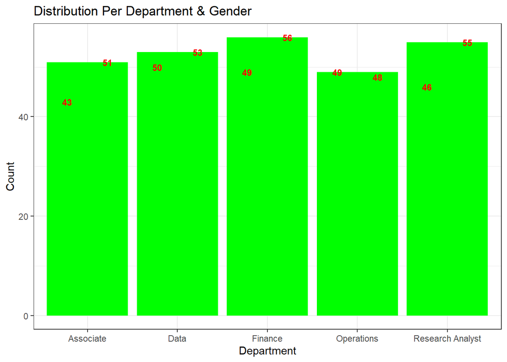

```r
Plot_bargraph <-  ggplot(data=Dep_Gender_bar,aes(x=Department, y=count, fill=Gender))+
  geom_bar(stat = "identity",fill="green", position = "dodge")+
  geom_text(aes(label=count),hjust=.5, vjust=.5,position=position_dodge(width = .9), size=3,fontface="bold",colour=factor("red"))+
  theme_bw()+
  scale_fill_brewer(palette = 1)+
  labs(title = "Distribution Per Department & Gender",
       x= "Department",
       y= "Count")
Plot_bargraph
```